# extras2

Here we run a simulation showing how the presence of multicollinearity in the data can affect the variability in the estimated regression coefficients.

where the variable $x_3$ is linearly dependent on $x_1$ and $x_2$ (more so with the $x_1$ than $x_2$—see the code). The constant `r` determines the extent of the multicollinearity—the smaller it is, the higher the multicollinearity between the variables.

The function `sim` runs the simulation `N` times and saves the regression coefficients, their standard errors, and their $p$-values. Below are histograms showing the variability in the estimated coefficients $b_1$, $b_2$, and $b_3$, under two values of $r$: 0.1 (lower multicollinearity) and 0.01 (higher multicollinearity).

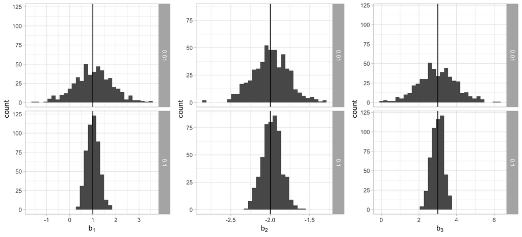

```r
## generate collinear data
collinear_datagen = function(n,r) {

  x1 = rnorm(n)
  x2 = rnorm(n)
  x3 = 0.8*x1 + 0.2*x2 + sqrt(r)*rnorm(n)
  y = x1 - 2*x2 + 3*x3 + rnorm(n)

  sample = data.frame(y,x1,x2,x3)

  model = summary(lm(y ~ x1 + x2 + x3, data = sample))
  modeldata = as.list(data.frame(model$coefficients[-1,c(1,2,4)]))
}

## run simulation
sim = function(N,n,r) {
  simulation = replicate(N, collinear_datagen(n,r))
  betas = do.call(rbind, simulation[1,])
  SEs =  do.call(rbind, simulation[2,])
  pvals =  do.call(rbind, simulation[3,])
  results = data.frame(cbind(betas, SEs, pvals))
  names(results) <- c("b_1", "b_2", "b_3", "SE_1", "SE_2", "SE_3", "pval_1", "pval_2", "pval_3")
  results
}

## save simulation data
mc1 = sim(500,100,0.1) #simulation with lower multicollinearity
mc01 = sim(500,100,0.01) #simulation with higher multicollinearity
mc1$r = "0.1"
mc01$r = "0.01"

mc = rbind(mc1,mc01)

## plots
plot1 = ggplot(mc, aes(b_1)) + geom_histogram(bins=30) + xlab(TeX("$b_1$")) + facet_grid(r~.) + geom_vline(xintercept = 1) + theme_light()
plot2 = ggplot(mc, aes(b_2)) + geom_histogram(bins=30) + xlab(TeX("$b_2$")) + facet_grid(r~.) + geom_vline(xintercept = -2) + theme_light()
plot3 = ggplot(mc, aes(b_3)) + geom_histogram(bins=30) + xlab(TeX("$b_3$")) + facet_grid(r~.) + geom_vline(xintercept = 3) + theme_light()

grid.arrange(plot1, plot2, plot3, ncol=3)
```

The vertical lines on the plots show the population coefficients—which are $\beta_1 = 1$, $\beta_2 = -2$, and $\beta_3 = 3$. It’s clear from these plots that the data with higher multicollinearity (with r = 0.01) has higher variability in its coefficient estimates.

```r
kable(cor(mc[ ,1:3]))
```

|  | b_1 | b_2 | b_3 |
| --- | --- | --- | --- |
| b_1 | 1.0000000 | 0.8221379 | -0.9861695 |
| b_2 | 0.8221379 | 1.0000000 | -0.8296747 |
| b_3 | -0.9861695 | -0.8296747 | 1.0000000 |

To see how this affects power, below is a table summarizing the power of each cofficient under $r=0.01$ and $r=0.1$:

```r
# see how this is reflected in the power
power = mc %>% group_by(r) %>% summarize(power_b1 = mean(pval_1 < 0.05), power_b2 = mean(pval_2 < 0.05), power_b3 = mean(pval_3 < 0.05))
kable(power)
```

| r | power_b1 | power_b2 | power_b3 |
| --- | --- | --- | --- |
| 0.01 | 0.224 | 1 | 0.83 |
| 0.1 | 0.946 | 1 | 1.00 |